# Height EDA

Joseph Marcus

11/25/2016

## Imports

```r
library(ggplot2)
library(dplyr)
library(tidyr)
library(knitr)
library(moments)
```

Here are some explortory analysis of gwas effects and allele frequencies where the sign of the effect is oriented to the derived allele (note if ancestral allele annontations is note availiable for a SNP I default to the globally minor allele). Specifically I downloaded human hieght gwas summary statisitcs of from the GIANT constorium. Our data consistents of about 2M SNPs. I applied `ash` to these summmary statistics and explore the relationship between effect sign, allele frequency and mutational context.

## Prepare data

Here I add to the df of summary statistics and ash results allele frequencies of derived alleles in the 1KG superpopulations (i.e. `f_sas, f_afr, f_eas, f_eur, f_amr`) as well as flanking reference genome bases one and two positions to the left and right of the snp (i.e. `ref_base_l2, ref_base_l1, ref_base_r1, ref_base_r2`). A string version of full 3mer and 5mer are in the `snp_mut_3mer, snp_mut_5mer` columns.

```r
# read summary statistics and add mutation columns
df <- readRDS(file = "../data/ash/giant_height_ash_df.rds") %>%
      mutate(sign = ifelse(beta_hat > 0, "+", "-")) %>%
      mutate(snp_mut=paste0(other_allele, "->", effect_allele)) %>%
      mutate(snp_mut_3mer = paste0(ref_base_l1, other_allele, "->", effect_allele, ref_base_r1)) %>%
      mutate(snp_mut_5mer = paste0(ref_base_l2, ref_base_l1, other_allele, "->", effect_allele, ref_base_r1, ref_base_r2)) %>%
      mutate(f_eur_tile = ntile(f_eur, 25))

head(df)
```

```
## # A tibble: 6 x 36
##   chrom    pos        snp allele_type effect_allele other_allele
##   <chr>  <int>      <chr>       <chr>         <chr>        <chr>
## 1     1 752566  rs3094315 minor_major             G            A
## 2     1 753541  rs2073813 minor_major             A            G
## 3     1 754192  rs3131968 minor_major             A            G
## 4     1 768448 rs12562034 minor_major             A            G
## 5     1 775659  rs2905035 minor_major             A            G
## 6     1 779322  rs4040617 minor_major             G            A
## # ... with 30 more variables: alt_allele <chr>, ref_allele <chr>,
## #   derived_allele <chr>, ancestral_allele <chr>, ref_base_l2 <chr>,
## #   ref_base_l1 <chr>, ref_base_r1 <chr>, ref_base_r2 <chr>, f_sas <dbl>,
## #   f_afr <dbl>, f_eas <dbl>, f_eur <dbl>, f_amr <dbl>, beta_hat <dbl>,
## #   se <dbl>, betahat <dbl>, sebetahat <dbl>, NegativeProb <dbl>,
## #   PositiveProb <dbl>, lfsr <dbl>, svalue <dbl>, lfdr <dbl>,
## #   qvalue <dbl>, PosteriorMean <dbl>, PosteriorSD <dbl>, sign <chr>,
## #   snp_mut <chr>, snp_mut_3mer <chr>, snp_mut_5mer <chr>,
## #   f_eur_tile <int>
```

```r
dim(df)
```

```
## [1] 2126678      36
```

```r
print(colnames(df))
```

```
##  [1] "chrom"            "pos"              "snp"
##  [4] "allele_type"      "effect_allele"    "other_allele"
##  [7] "alt_allele"       "ref_allele"       "derived_allele"
## [10] "ancestral_allele" "ref_base_l2"      "ref_base_l1"
## [13] "ref_base_r1"      "ref_base_r2"      "f_sas"
## [16] "f_afr"            "f_eas"            "f_eur"
## [19] "f_amr"            "beta_hat"         "se"
## [22] "betahat"          "sebetahat"        "NegativeProb"
## [25] "PositiveProb"     "lfsr"             "svalue"
## [28] "lfdr"             "qvalue"           "PosteriorMean"
## [31] "PosteriorSD"      "sign"             "snp_mut"
## [34] "snp_mut_3mer"     "snp_mut_5mer"     "f_eur_tile"
```

## Allele frequency spectrum (AFS)

### Derived AFS and global minor AFS

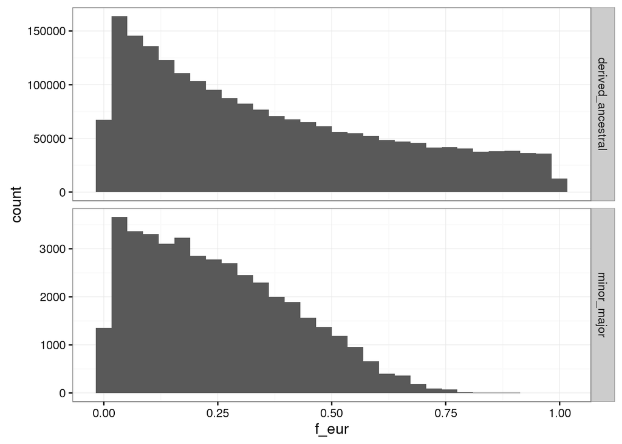

```r
p <- ggplot(df, aes(x=f_eur)) +
     geom_histogram() +
     facet_grid(allele_type ~ ., scales = "free") +
     theme_bw()
p
```

### Dervied AFS vs effect sign

As observed previously we observe an enrichment of negative effect SNPs in the rare side of the frequency spectrum (the community has invoked selection to explain this observation).

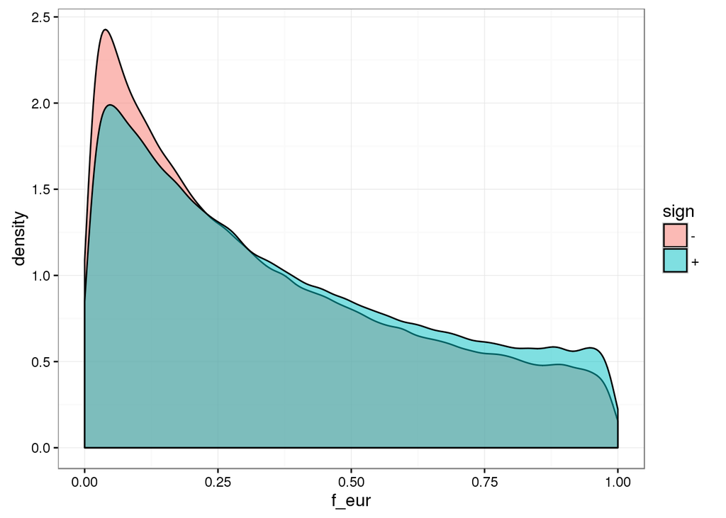

```r
p <- ggplot(df %>% filter(allele_type == "derived_ancestral"), aes(x=f_eur, fill=sign)) +
     geom_density(alpha=.5) +
     theme_bw()
p
```

*Need to figure out a better visualization for posterior signs*

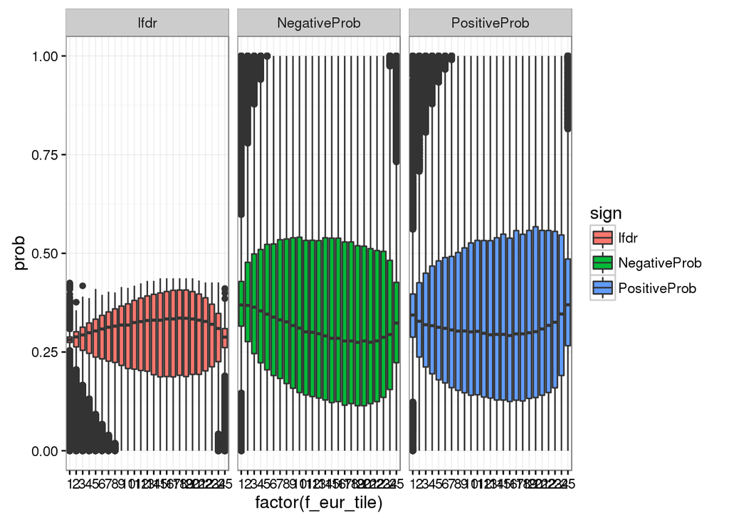

```r
gath_ash_sign_df <- df %>% filter(allele_type == "derived_ancestral") %>%
                    select(snp, f_eur_tile, NegativeProb, PositiveProb, lfdr) %>%
                    gather(sign, prob, -snp, -f_eur_tile)

p <- ggplot(gath_ash_sign_df, aes(x=factor(f_eur_tile), y=prob, fill=sign)) +
     geom_boxplot() +
     theme_bw() + facet_grid(~sign)
p
```

Note I filter out strand ambigous SNPs so that is why we are missing A/T and G/C mutations.

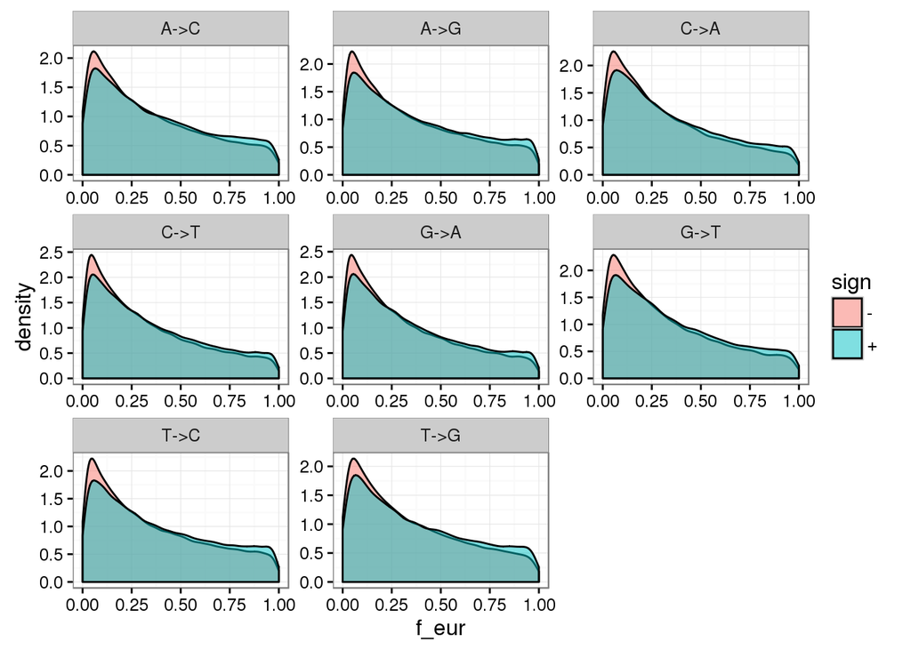

```r
p <- ggplot(df %>% filter(allele_type=="derived_ancestral"), aes(x=f_eur, fill=sign)) +
     geom_density(alpha=.5) +
     facet_wrap(~snp_mut, scales = "free") +
     theme_bw()
p
```

## Mutation types vs effects

### 3mer effect size distributions

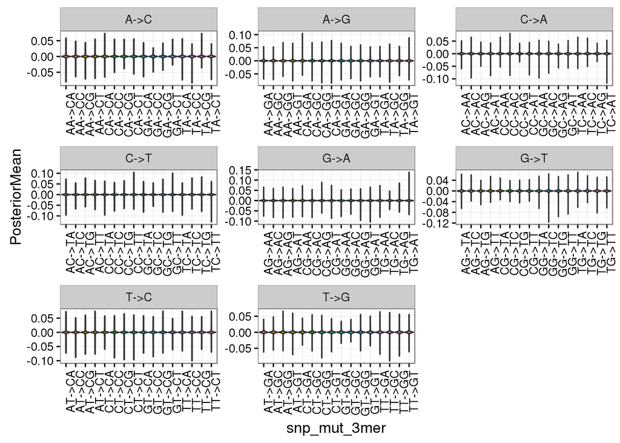

```r
p <- ggplot(df, aes(x=snp_mut_3mer, y=PosteriorMean, fill=paste0(ref_base_l1, ref_base_r1))) +
     geom_violin() +
     facet_wrap(~snp_mut,scales = "free") +
     theme_bw() +
     theme(axis.text.x = element_text(angle = 90, hjust = 1)) +
     guides(fill=FALSE)
p
```

```r
x <- df %>% filter(snp_mut_3mer == "TG->AT")
```